# B4BI Pak Choi Seed Data Graphs and Models

Heather Jenkins

29 September 2026

# Overview

This document contains some analysis of the previously cleaned seed data.

This analysis was performed using R version 4.6.1 (2026-06-24 ucrt). The *tidyverse* suite of packages was used for data manipulation and visualisation. The *emmeans* package was used for model predictions.

# Data Loading

The cleaned data is read in. There is the full dataset followed by the dataset that has been summarised (over the unbalanced reps).

```
## tibble [4,315 × 16] (S3: tbl_df/tbl/data.frame)
##  $ Year                    : Factor w/ 3 levels "2021-2022","2022-2023",..: 1 1 1 1 1 1 1 1 1 1 ...
##  $ Farm                    : Factor w/ 19 levels "Ahuriri","Ashford 1",..: 6 6 6 6 6 6 6 6 6 6 ...
##  $ Property_Grouping       : Factor w/ 18 levels "Ahuriri","Ashford_1",..: 6 6 6 6 6 6 6 6 6 6 ...
##  $ PK_Boundary             : Factor w/ 10 levels "Bare_fence","Control_farm",..: 1 1 1 1 1 1 1 2 2 2 ...
##  $ Simplified_Boundary     : Factor w/ 4 levels "Old native","New native",..: 3 3 3 3 3 3 3 4 4 4 ...
##  $ Very_Simplified_Boundary: Factor w/ 2 levels "Bare_fence","Mixed_native": 1 1 1 1 1 1 1 1 1 1 ...
##  $ Planting_date           : chr [1:4315] "*" "*" "*" "*" ...
##  $ Treatment               : Factor w/ 3 levels "Hand pollinated",..: 1 1 1 1 1 1 1 1 1 1 ...
##  $ Colour                  : logi [1:4315] NA NA NA NA NA NA ...
##  $ Rep                     : num [1:4315] 2 2 2 2 1 1 1 2 2 2 ...
##  $ Number_of_Pods          : chr [1:4315] "10" "10" "10" "10" ...
##  $ Pod_number              : chr [1:4315] "7" "10" "3" "1" ...
##  $ Seed viable             : num [1:4315] 13 12 12 10 13 15 16 16 11 12 ...
##  $ Seed inviable           : num [1:4315] 0 0 1 0 0 0 0 0 0 0 ...
##  $ Native_new_age          : Factor w/ 6 levels "Old native","Three-year old native",..: 5 5 5 5 5 5 5 6 6 6 ...
##  $ Type_of_farm            : Factor w/ 2 levels "Arable","Dairy": 2 2 2 2 2 2 2 2 2 2 ...
```

Next the previously saved summarised data is loaded.

```
## tibble [319 × 7] (S3: tbl_df/tbl/data.frame)
##  $ Year               : Factor w/ 3 levels "2021-2022","2022-2023",..: 1 1 1 1 1 1 1 1 1 1 ...
##  $ Farm               : Factor w/ 19 levels "Ahuriri","Ashford 1",..: 1 1 1 1 1 2 2 2 2 2 ...
##  $ Type_of_farm       : Factor w/ 2 levels "Arable","Dairy": 1 1 1 1 1 2 2 2 2 2 ...
##  $ Simplified_Boundary: Factor w/ 4 levels "Old native","New native",..: 2 2 2 4 4 2 2 2 4 4 ...
##  $ Native_new_age     : Factor w/ 6 levels "Old native","Three-year old native",..: 4 4 4 6 6 4 4 4 6 6 ...
##  $ Treatment          : Factor w/ 3 levels "Hand pollinated",..: 1 2 3 1 2 1 2 3 1 2 ...
##  $ Mean_seeds_viable  : num [1:319] 16.2 14.8 1 16.2 10.4 ...
```

Next we further summarise the data and calculate the means for each Year, Simplified_Boundary and Treatment combination (the black dots in the second and third graphs below).

# Graphs

## With the farms shown

[figure not shown]

The details of the particular farms is not of interest so we remove this information and add the overall means to the plots.

## With the overall raw means

The two plots below are the same, just with minor differences (HP abbreviation and the size of the points).

[figure not shown]

## Dairy or Arable added to the graphs

First we look at the data in a single graph and then with the farm types separated.

[figure not shown]

# Modelling

## Comments

- We remove the Control farms and the Closed treatment so we can see if there is a difference between HP and Open.
- Fitting a zero-inflated model with the Closed treatment data included did not converge. Since this was not the “main comparison of interest” I did not spend a lot time trying to make it work.
- The data is separated into Arable and Dairy for modelling purposes.
- Again I ran into problems with trying to fit a single model.

## Model descriptions

We fit linear mixed-effect models to the two sets of data. The response is Mean_seeds_viable. The fixed-effects are Treatment and Simplified_Boundary plus their two-way interaction. Year is not really of interest (I hope?) so we make it a random effect. There is also a random effect for Farm nested in Year. This means that there are 3 levels to the Year random effect, and 24 for the Farm:Year random effect (and it doesn’t matter that we don’t have data from every farm for each year).

## Graphs of data used in models

[figure not shown]

## Results Arable farms

If the two outliers are removed from the data the modelling assumptions are better satisfied (results not shown).

The story is the same with the outliers in the model so they are not removed.

The ANOVA table is:

|  | Chisq | Df | Pr(>Chisq) |
| --- | --- | --- | --- |
| Treatment | 45.67797 | 1 | 0.000000 |
| Simplified_Boundary | 17.19781 | 2 | 0.000184 |
| Treatment:Simplified_Boundary | 15.54016 | 2 | 0.000422 |

The two-way interaction is significant. The modelled/predicted means and 95% confidence intervals are graphed and given in a table. Note that the post-hoc pairwise comparison p-values were adjusted using the FDR correction to account for multiple tests.

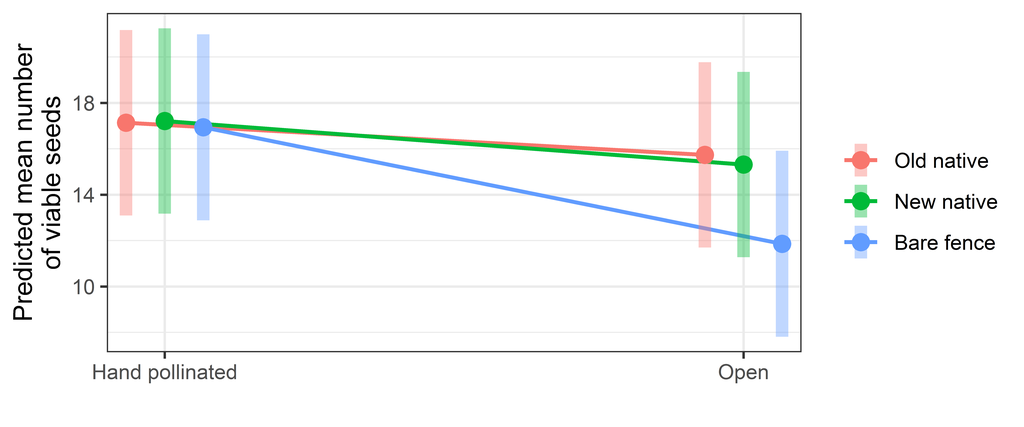

| Simplified_Boundary | Treatment | Predicted mean | lower.CL | upper.CL |
| --- | --- | --- | --- | --- |
| Old native | Hand pollinated | 17.14 | 10.90 | 23.37 |
| New native | Hand pollinated | 17.21 | 10.98 | 23.44 |
| Bare fence | Hand pollinated | 16.94 | 10.66 | 23.21 |
| Old native | Open | 15.74 | 9.50 | 21.97 |
| New native | Open | 15.31 | 9.08 | 21.54 |
| Bare fence | Open | 11.86 | 5.59 | 18.14 |

[figure not shown]

```
## Treatment = Hand pollinated:
##  contrast                estimate    SE   df t.ratio p.value
##  Old native - New native  -0.0746 0.853 69.2  -0.087  0.9306
##  Old native - Bare fence   0.1988 0.739 52.6   0.269  0.9306
##  New native - Bare fence   0.2734 0.827 67.2   0.331  0.9306
##
## Treatment = Open:
##  contrast                estimate    SE   df t.ratio p.value
##  Old native - New native   0.4242 0.853 69.2   0.497  0.6206
##  Old native - Bare fence   3.8749 0.739 52.6   5.242 <0.0001
##  New native - Bare fence   3.4508 0.827 67.2   4.172  0.0001
##
## Degrees-of-freedom method: kenward-roger
## P value adjustment: fdr method for 3 tests
```

## Results Dairy farms

The ANOVA table is:

|  | Chisq | Df | Pr(>Chisq) |
| --- | --- | --- | --- |
| Simplified_Boundary | 25.565 | 2 | 0.000 |
| Treatment | 32.257 | 1 | 0.000 |
| Simplified_Boundary:Treatment | 9.679 | 2 | 0.008 |

The two-way interaction is significant. The modelled/predicted means and 95% confidence intervals are graphed and given in a table.

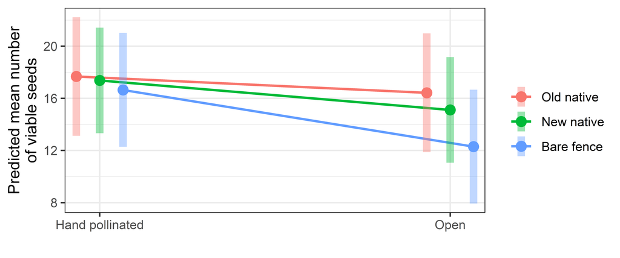

| Simplified_Boundary | Treatment | Predicted mean | lower.CL | upper.CL |
| --- | --- | --- | --- | --- |
| Old native | Hand pollinated | 17.68 | 10.29 | 25.07 |
| New native | Hand pollinated | 17.37 | 11.46 | 23.29 |
| Bare fence | Hand pollinated | 16.64 | 9.81 | 23.48 |
| Old native | Open | 16.43 | 9.04 | 23.82 |
| New native | Open | 15.11 | 9.20 | 21.03 |
| Bare fence | Open | 12.30 | 5.46 | 19.13 |

[figure not shown]

```
## Treatment = Hand pollinated:
##  contrast                estimate    SE   df t.ratio p.value
##  Old native - New native    0.303 0.896 79.5   0.338  0.7363
##  Old native - Bare fence    1.033 0.719 67.8   1.437  0.4664
##  New native - Bare fence    0.730 0.935 77.1   0.781  0.6559
##
## Treatment = Open:
##  contrast                estimate    SE   df t.ratio p.value
##  Old native - New native    1.315 0.896 79.5   1.467  0.1464
##  Old native - Bare fence    4.132 0.719 67.8   5.747 <0.0001
##  New native - Bare fence    2.818 0.935 77.1   3.014  0.0052
##
## Degrees-of-freedom method: kenward-roger
## P value adjustment: fdr method for 3 tests
```

The table above shows pairwise Simplified_Boundary comparisons for each of the Treatments. There is no difference for Hand pollinated.

For Open, the New native have approximately 3 more viable seeds on average than the Bare fence. The Old native have approximately 4 more viable seeds on average than the Bare fence. There is no difference between New native and Old native.

# Modelling (Updated so ‘New Native’ & Year one-to-one relationship)

We repeat the above with ‘one year native’ and ‘two year native’ in 2023-2024 removed. So ‘New native’ only has

- One year old in 2021-2022
- Two year old in 2022-2023
- Three year old in 2023-2024

Note that is data is all from Arable farms (Garrickfield and Limbrick).

Tables of counts before and after the four extra observations are removed are below:

```
##
##             Old native Three-year old native Two-year old native
##   2021-2022         24                     0                   0
##   2022-2023         24                     0                  14
##   2023-2024         20                    14                   2
##
##             One-year old native On-farm bare fence Off-farm bare fence
##   2021-2022                  12                 20                   2
##   2022-2023                   0                 20                   2
##   2023-2024                   2                 12                   2
```

```
##
##             Old native Three-year old native Two-year old native
##   2021-2022         24                     0                   0
##   2022-2023         24                     0                  14
##   2023-2024         20                    14                   0
##
##             One-year old native On-farm bare fence Off-farm bare fence
##   2021-2022                  12                 20                   2
##   2022-2023                   0                 20                   2
##   2023-2024                   0                 12                   2
```

## Model descriptions

We fit linear mixed-effect models to the two sets of data. The response is Mean_seeds_viable. The fixed-effects are Treatment and Simplified_Boundary plus their two-way interaction. Year is not really of interest (I hope?) so we make it a random effect. There is also a random effect for Farm nested in Year. This means that there are 3 levels to the Year random effect, and 24 for the Farm:Year random effect (and it doesn’t matter that we don’t have data from every farm for each year).

## Graphs of data used in models

[figure not shown]

## Results Arable farms

The two outliers are not removed from the data. Removing them better satisfies modelling assumptions, but does not change the story (results not shown).

The ANOVA table is:

|  | Chisq | Df | Pr(>Chisq) |
| --- | --- | --- | --- |
| Treatment | 40.63640 | 1 | 0.000000 |
| Simplified_Boundary | 18.00456 | 2 | 0.000123 |
| Treatment:Simplified_Boundary | 17.43491 | 2 | 0.000164 |

The two-way interaction is significant. The modelled/predicted means and 95% confidence intervals are graphed and given in a table. Note that the post-hoc pairwise comparison p-values were adjusted using the FDR correction to account for multiple tests.

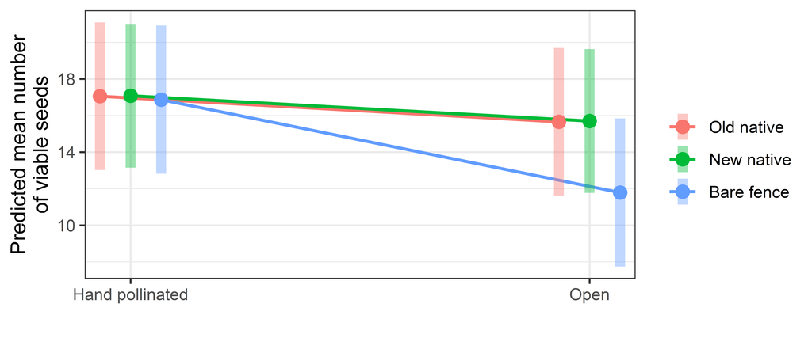

| Simplified_Boundary | Treatment | Predicted mean | lower.CL | upper.CL |
| --- | --- | --- | --- | --- |
| Old native | Hand pollinated | 17.06 | 10.83 | 23.28 |
| New native | Hand pollinated | 17.08 | 11.16 | 23.00 |
| Bare fence | Hand pollinated | 16.87 | 10.59 | 23.14 |
| Old native | Open | 15.66 | 9.43 | 21.88 |
| New native | Open | 15.70 | 9.78 | 21.62 |
| Bare fence | Open | 11.79 | 5.52 | 18.07 |

[figure not shown]

```
## Treatment = Hand pollinated:
##  contrast                estimate    SE   df t.ratio p.value
##  Old native - New native  -0.0238 0.909 66.0  -0.026  0.9792
##  Old native - Bare fence   0.1891 0.735 49.4   0.257  0.9792
##  New native - Bare fence   0.2129 0.879 65.0   0.242  0.9792
##
## Treatment = Open:
##  contrast                estimate    SE   df t.ratio p.value
##  Old native - New native  -0.0430 0.909 66.0  -0.047  0.9624
##  Old native - Bare fence   3.8652 0.735 49.4   5.258 <0.0001
##  New native - Bare fence   3.9082 0.879 65.0   4.448 <0.0001
##
## Degrees-of-freedom method: kenward-roger
## P value adjustment: fdr method for 3 tests
```

The table above shows pairwise Simplified_Boundary comparisons for each of the Treatments. There is no difference for Hand pollinated. For Open the New native and Old native each have approximately 3-4 more viable seeds on average than the Bare fence. There is no difference between New native and Old native.

## Results Dairy farms (unchanged)

The ANOVA table is:

|  | Chisq | Df | Pr(>Chisq) |
| --- | --- | --- | --- |
| Simplified_Boundary | 25.565 | 2 | 0.000 |
| Treatment | 32.257 | 1 | 0.000 |
| Simplified_Boundary:Treatment | 9.679 | 2 | 0.008 |

The two-way interaction is significant. The modelled/predicted means and 95% confidence intervals are graphed and given in a table.

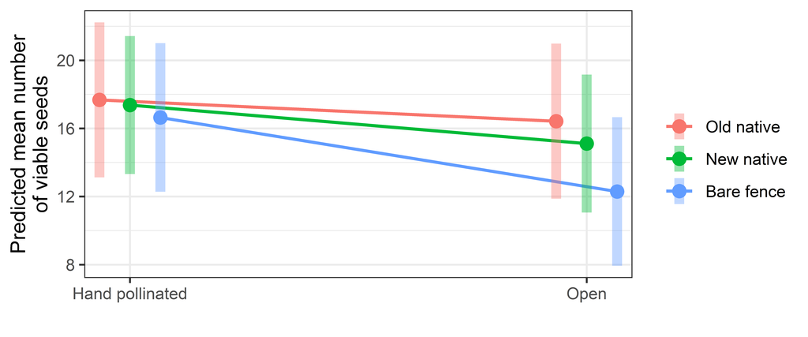

| Simplified_Boundary | Treatment | Predicted mean | lower.CL | upper.CL |
| --- | --- | --- | --- | --- |
| Old native | Hand pollinated | 17.68 | 10.29 | 25.07 |
| New native | Hand pollinated | 17.37 | 11.46 | 23.29 |
| Bare fence | Hand pollinated | 16.64 | 9.81 | 23.48 |
| Old native | Open | 16.43 | 9.04 | 23.82 |
| New native | Open | 15.11 | 9.20 | 21.03 |
| Bare fence | Open | 12.30 | 5.46 | 19.13 |

[figure not shown]

```
## Treatment = Hand pollinated:
##  contrast                estimate    SE   df t.ratio p.value
##  Old native - New native    0.303 0.896 79.5   0.338  0.7363
##  Old native - Bare fence    1.033 0.719 67.8   1.437  0.4664
##  New native - Bare fence    0.730 0.935 77.1   0.781  0.6559
##
## Treatment = Open:
##  contrast                estimate    SE   df t.ratio p.value
##  Old native - New native    1.315 0.896 79.5   1.467  0.1464
##  Old native - Bare fence    4.132 0.719 67.8   5.747 <0.0001
##  New native - Bare fence    2.818 0.935 77.1   3.014  0.0052
##
## Degrees-of-freedom method: kenward-roger
## P value adjustment: fdr method for 3 tests
```

The table above shows pairwise Simplified_Boundary comparisons for each of the Treatments. There is no difference for Hand pollinated.

For Open, the New native have approximately 3 more viable seeds on average than the Bare fence. The Old native have approximately 4 more viable seeds on average than the Bare fence. There is no difference between New native and Old native.

# NEW Modelling with Age of New Natives

## Model descriptions

We fit linear mixed-effect models to the two sets of data. The response is Mean_seeds_viable. The fixed-effects are Treatment and Native_new_age plus their two-way interaction. Year is random effect. There is also a random effect for Farm nested in Year. This means that there are 3 levels to the Year random effect, and 24 for the Farm:Year random effect (and it doesn’t matter that we don’t have data from every farm for each year).

## Results Arable farms

Two outliers were removed from the data to better satisfy modelling assumptions.

If the outliers are included in the model, the story is the same (results not shown).

The ANOVA table is:

|  | Chisq | Df | Pr(>Chisq) |
| --- | --- | --- | --- |
| Treatment | 66.15311 | 1 | 0.000000 |
| Native_new_age | 26.07402 | 5 | 0.000086 |
| Treatment:Native_new_age | 21.85323 | 5 | 0.000558 |

The two-way interaction is significant. The modelled/predicted means and 95% confidence intervals are graphed and given in a table. Note that the post-hoc pairwise comparison p-values were adjusted using the FDR correction to account for multiple tests.

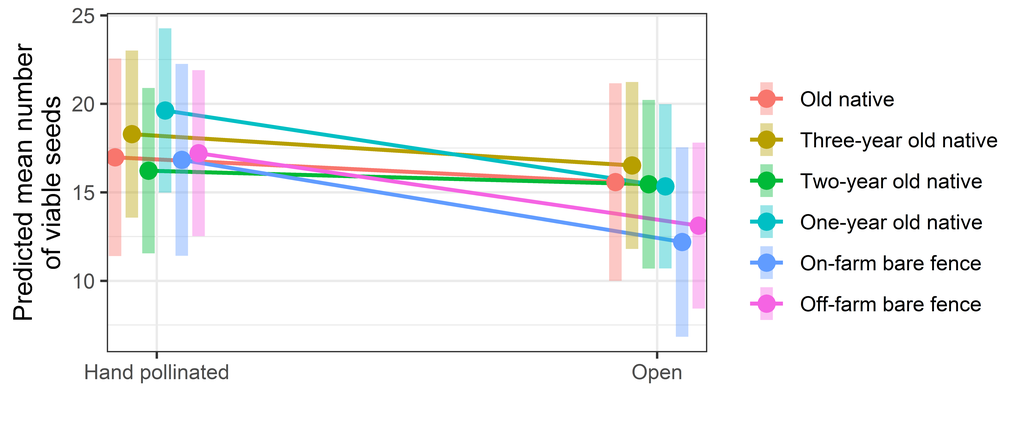

| Native_new_age | Treatment | Predicted mean | lower.CL | upper.CL |
| --- | --- | --- | --- | --- |
| Old native | Hand pollinated | 16.98 | 4.14 | 29.82 |
| Three-year old native | Hand pollinated | 18.29 | 9.95 | 26.62 |
| Two-year old native | Hand pollinated | 16.22 | 8.14 | 24.31 |
| One-year old native | Hand pollinated | 19.62 | 11.82 | 27.43 |
| On-farm bare fence | Hand pollinated | 16.83 | 4.83 | 28.83 |
| Off-farm bare fence | Hand pollinated | 17.21 | 8.95 | 25.47 |
| Old native | Open | 15.58 | 2.74 | 28.42 |
| Three-year old native | Open | 16.52 | 8.18 | 24.85 |
| Two-year old native | Open | 15.45 | 6.86 | 24.04 |
| One-year old native | Open | 15.34 | 7.53 | 23.15 |
| On-farm bare fence | Open | 12.19 | 0.52 | 23.85 |
| Off-farm bare fence | Open | 13.12 | 4.85 | 21.38 |

[figure not shown]

```
## Treatment = Hand pollinated:
##  contrast                                        estimate    SE   df t.ratio
##  Old native - (Three-year old native)              -1.310 1.090 49.4  -1.206
##  Old native - (Two-year old native)                 0.756 1.110 57.0   0.679
##  Old native - (One-year old native)                -2.645 1.210 52.4  -2.180
##  Old native - (On-farm bare fence)                  0.147 0.603 41.6   0.244
##  Old native - (Off-farm bare fence)                -0.233 1.090 57.9  -0.215
##  (Three-year old native) - (Two-year old native)    2.066 1.450 59.0   1.428
##  (Three-year old native) - (One-year old native)   -1.334 1.510 56.4  -0.882
##  (Three-year old native) - (On-farm bare fence)     1.457 1.110 50.2   1.309
##  (Three-year old native) - (Off-farm bare fence)    1.077 1.290 56.7   0.832
##  (Two-year old native) - (One-year old native)     -3.400 1.530 59.0  -2.218
##  (Two-year old native) - (On-farm bare fence)      -0.609 1.160 57.5  -0.526
##  (Two-year old native) - (Off-farm bare fence)     -0.989 1.320 51.5  -0.749
##  (One-year old native) - (On-farm bare fence)       2.792 1.240 53.0   2.252
##  (One-year old native) - (Off-farm bare fence)      2.411 1.360 55.5   1.770
##  (On-farm bare fence) - (Off-farm bare fence)      -0.381 1.120 57.9  -0.341
##  p.value
##   0.5004
##   0.6814
##   0.1688
##   0.8305
##   0.8305
##   0.4753
##   0.6811
##   0.4912
##   0.6811
##   0.1688
##   0.7514
##   0.6814
##   0.1688
##   0.3083
##   0.8305
##
## Treatment = Open:
##  contrast                                        estimate    SE   df t.ratio
##  Old native - (Three-year old native)              -0.937 1.090 49.4  -0.863
##  Old native - (Two-year old native)                 0.125 1.040 58.7   0.120
##  Old native - (One-year old native)                 0.239 1.210 52.4   0.197
##  Old native - (On-farm bare fence)                  3.389 0.625 41.9   5.418
```

[output cut: 15 more lines]

```
##  <0.0001
##   0.0675
##   0.5617
##   0.5617
##   0.0025
##   0.0413
##   0.9389
##   0.0222
##   0.1533
##   0.0439
##   0.2028
##   0.5617
##
## Degrees-of-freedom method: kenward-roger
## P value adjustment: fdr method for 15 tests
```

The table above shows pairwise Native_new_age comparisons for each of the Treatments. There are no differences for Hand pollinated. For Open, the ‘Two-year old native’, ‘Three-year old native’ and ‘Old native’ each have 3-4 more viable seeds on average than ‘On-farm bare fence’. There are other statistically significant differences.

## Results Dairy farms

The ANOVA table is:

|  | Chisq | Df | Pr(>Chisq) |
| --- | --- | --- | --- |
| Treatment | 36.19456 | 1 | 0.000000 |
| Native_new_age | 33.07631 | 4 | 0.000001 |
| Treatment:Native_new_age | 17.25479 | 4 | 0.001725 |

The two-way interaction is significant. The modelled/predicted means and 95% confidence intervals are graphed and given in a table.

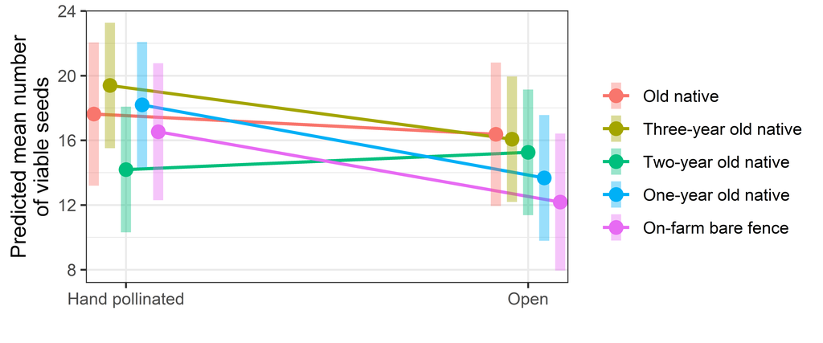

| Native_new_age | Treatment | Predicted mean | lower.CL | upper.CL |
| --- | --- | --- | --- | --- |
| Old native | Hand pollinated | 17.63 | 8.57 | 26.68 |
| Three-year old native | Hand pollinated | 19.39 | 13.83 | 24.96 |
| Two-year old native | Hand pollinated | 14.20 | 8.62 | 19.77 |
| One-year old native | Hand pollinated | 18.20 | 12.63 | 23.77 |
| On-farm bare fence | Hand pollinated | 16.53 | 8.36 | 24.71 |
| Old native | Open | 16.38 | 7.32 | 25.43 |
| Three-year old native | Open | 16.07 | 10.51 | 21.63 |
| Two-year old native | Open | 15.26 | 9.69 | 20.83 |
| One-year old native | Open | 13.68 | 8.10 | 19.25 |
| On-farm bare fence | Open | 12.18 | 4.01 | 20.36 |

[figure not shown]

```
## Treatment = Hand pollinated:
##  contrast                                        estimate    SE   df t.ratio
##  Old native - (Three-year old native)              -1.766 1.400 74.5  -1.258
##  Old native - (Two-year old native)                 3.430 1.380 76.6   2.483
##  Old native - (One-year old native)                -0.571 1.380 76.6  -0.413
##  Old native - (On-farm bare fence)                  1.093 0.681 63.2   1.606
##  (Three-year old native) - (Two-year old native)    5.197 1.900 76.2   2.734
##  (Three-year old native) - (One-year old native)    1.195 1.900 76.2   0.629
##  (Three-year old native) - (On-farm bare fence)     2.860 1.440 72.2   1.987
##  (Two-year old native) - (One-year old native)     -4.002 1.880 77.5  -2.133
##  (Two-year old native) - (On-farm bare fence)      -2.337 1.400 76.0  -1.674
##  (One-year old native) - (On-farm bare fence)       1.664 1.400 76.0   1.192
##  p.value
##   0.2962
##   0.0760
##   0.6804
##   0.1889
##   0.0760
##   0.5904
##   0.1267
##   0.1203
##   0.1889
##   0.2962
##
## Treatment = Open:
##  contrast                                        estimate    SE   df t.ratio
##  Old native - (Three-year old native)               0.307 1.400 74.5   0.219
##  Old native - (Two-year old native)                 1.120 1.380 76.6   0.811
##  Old native - (One-year old native)                 2.701 1.380 76.6   1.955
##  Old native - (On-farm bare fence)                  4.193 0.681 63.2   6.158
##  (Three-year old native) - (Two-year old native)    0.813 1.900 76.2   0.428
##  (Three-year old native) - (One-year old native)    2.394 1.900 76.2   1.260
##  (Three-year old native) - (On-farm bare fence)     3.886 1.440 72.2   2.701
##  (Two-year old native) - (One-year old native)      1.581 1.880 77.5   0.843
##  (Two-year old native) - (On-farm bare fence)       3.073 1.400 76.0   2.201
##  (One-year old native) - (On-farm bare fence)       1.492 1.400 76.0   1.068
##  p.value
##   0.8276
##   0.5249
##   0.1355
##  <0.0001
##   0.7444
##   0.4233
##   0.0431
##   0.5249
##   0.1026
##   0.4812
##
## Degrees-of-freedom method: kenward-roger
## P value adjustment: fdr method for 10 tests
```

The table above shows pairwise Native_new_age comparisons for each of the Treatments. There is no difference for ‘Hand pollinated’.

For Open, ‘Old native’ and ‘Three-year old native’ each have 4 more viable seeds on average than the ‘On-face bare fence’. There are no other statistically different pairs.